# Parte 2 del trabajo final: Indicadores de desarrollo global

Integrantes:

- Alex Alberth Cuya Aliaga
- Jesús Mio Ari
- Luis Huaranca Novoa
- Andrea Quispe Maslucán

## Fuerza laboral femenina en el Perú

```python
import pandas as pd
import matplotlib.pyplot as plt
import seaborn as sns
import numpy as np
from scipy.stats import norm
from scipy import stats
```

### 1. Obtener el porcentaje de fuerza laboral femenina para Perú

```python
female_lf = pd.read_csv('desarrollo_global.csv')

peru_flf = female_lf.loc[((female_lf['Country Name'] == 'Peru') & (female_lf['Series Name'] == 'Labor force, female (% of total labor force)'))]
peru_flf = peru_flf[peru_flf.columns[~peru_flf.columns.isin(['Country Name', 'Country Code', 'Series Name','Series Code'])]]

peru_flf
```

|  | 1960 [YR1960] | 1961 [YR1961] | 1962 [YR1962] | 1963 [YR1963] | 1964 [YR1964] | 1965 [YR1965] | 1966 [YR1966] | 1967 [YR1967] | 1968 [YR1968] | 1969 [YR1969] | ... | 2013 [YR2013] | 2014 [YR2014] | 2015 [YR2015] | 2016 [YR2016] | 2017 [YR2017] | 2018 [YR2018] | 2019 [YR2019] | 2020 [YR2020] | 2021 [YR2021] | 2022 [YR2022] |
| --- | --- | --- | --- | --- | --- | --- | --- | --- | --- | --- | --- | --- | --- | --- | --- | --- | --- | --- | --- | --- | --- |
| 929 | .. | .. | .. | .. | .. | .. | .. | .. | .. | .. | ... | 45.8711092036968 | 45.804310150231 | 45.4276000599438 | 45.7818223870905 | 45.9158254902167 | 46.1114156983427 | 46.1284202883485 | 44.2865347211395 | 45.975899260784 | 46.7458159089724 |

1 rows × 63 columns

Luego de filtrar los datos, se edita el nombre de las columnas para que solo figure el año

```python
yrs = list(peru_flf.columns)

for i in range(len(yrs)):
    yrs[i] = yrs[i][:4]

print(yrs)
```

```
['1960', '1961', '1962', '1963', '1964', '1965', '1966', '1967', '1968', '1969', '1970', '1971', '1972', '1973', '1974', '1975', '1976', '1977', '1978', '1979', '1980', '1981', '1982', '1983', '1984', '1985', '1986', '1987', '1988', '1989', '1990', '1991', '1992', '1993', '1994', '1995', '1996', '19…
```

Ahora se va a cambiar el nombre de las columnas con la lista generada anteriormente, reemplazar los missing values con numpy para que sean de tipo float, y convertir todos los valores del data frame a float.

```python
peru_flf.columns = yrs
peru_flf.replace('..', np.nan, inplace=True)
peru_flf = peru_flf.astype(float)
peru_flf
```

|  | 1960 | 1961 | 1962 | 1963 | 1964 | 1965 | 1966 | 1967 | 1968 | 1969 | ... | 2013 | 2014 | 2015 | 2016 | 2017 | 2018 | 2019 | 2020 | 2021 | 2022 |
| --- | --- | --- | --- | --- | --- | --- | --- | --- | --- | --- | --- | --- | --- | --- | --- | --- | --- | --- | --- | --- | --- |
| 929 | NaN | NaN | NaN | NaN | NaN | NaN | NaN | NaN | NaN | NaN | ... | 45.871109 | 45.80431 | 45.4276 | 45.781822 | 45.915825 | 46.111416 | 46.12842 | 44.286535 | 45.975899 | 46.745816 |

1 rows × 63 columns

Para facilitar el merge, se va a transponer el data frame generado.

```python
tperu_flf = peru_flf.transpose()
tperu_flf.columns = ['fl_peru']
tperu_flf
```

|  | fl_peru |
| --- | --- |
| 1960 | NaN |
| 1961 | NaN |
| 1962 | NaN |
| 1963 | NaN |
| 1964 | NaN |
| ... | ... |
| 2018 | 46.111416 |
| 2019 | 46.128420 |
| 2020 | 44.286535 |
| 2021 | 45.975899 |
| 2022 | 46.745816 |

63 rows × 1 columns

### 2. Obtener el porcentaje de fuerza laboral femenina promedio para Latinoamérica y el Caribe

Para filtrar los datos, se empleará una lista con los países que el Banco Mundial registra como parte de la región Latinoamérica y el Caribe. Seguidamente, se repiten los mismos pasos que para el caso de Perú.

```python
lac = [
    "Antigua and Barbuda", "Argentina", "Aruba", "Bahamas, The", "Barbados", "Belize", "Bolivia", "Brazil",
    "British Virgin Islands", "Cayman Islands", "Chile", "Colombia", "Costa Rica", "Cuba", "Curacao",
    "Dominica", "Dominican Republic", "Ecuador", "El Salvador", "Grenada", "Guatemala", "Guyana", "Haiti",
    "Honduras", "Jamaica", "Mexico", "Nicaragua", "Panama", "Paraguay", "Peru", "Puerto Rico",
    "Sint Maarten (Dutch part)", "St. Kitts and Nevis", "St. Lucia", "St. Martin (French part)",
    "St. Vincent and the Grenadines", "Suriname", "Trinidad and Tobago", "Turks and Caicos Islands",
    "Uruguay", "Venezuela, RB", "Virgin Islands (U.S.)"
]

lac_flf = female_lf.loc[((female_lf['Country Name'].isin(lac)) & (female_lf['Series Name'] == 'Labor force, female (% of total labor force)'))]
lac_flf = lac_flf[lac_flf.columns[~lac_flf.columns.isin(['Country Name', 'Country Code', 'Series Name','Series Code'])]]
lac_flf.columns = yrs
lac_flf.replace('..', np.nan, inplace=True)
lac_flf = lac_flf.astype(float)
lac_flf
```

|  | 1960 | 1961 | 1962 | 1963 | 1964 | 1965 | 1966 | 1967 | 1968 | 1969 | ... | 2013 | 2014 | 2015 | 2016 | 2017 | 2018 | 2019 | 2020 | 2021 | 2022 |
| --- | --- | --- | --- | --- | --- | --- | --- | --- | --- | --- | --- | --- | --- | --- | --- | --- | --- | --- | --- | --- | --- |
| 41 | NaN | NaN | NaN | NaN | NaN | NaN | NaN | NaN | NaN | NaN | ... | NaN | NaN | NaN | NaN | NaN | NaN | NaN | NaN | NaN | NaN |
| 47 | NaN | NaN | NaN | NaN | NaN | NaN | NaN | NaN | NaN | NaN | ... | 40.672927 | 40.823464 | 41.025023 | 41.233085 | 41.441271 | 42.146220 | 42.376056 | 42.393834 | 42.533911 | 43.081417 |
| 59 | NaN | NaN | NaN | NaN | NaN | NaN | NaN | NaN | NaN | NaN | ... | NaN | NaN | NaN | NaN | NaN | NaN | NaN | NaN | NaN | NaN |
| 83 | NaN | NaN | NaN | NaN | NaN | NaN | NaN | NaN | NaN | NaN | ... | 47.458684 | 47.519201 | 47.526261 | 47.602709 | 47.762798 | 47.913278 | 47.962261 | 47.953544 | 48.142620 | 48.389667 |
| 101 | NaN | NaN | NaN | NaN | NaN | NaN | NaN | NaN | NaN | NaN | ... | 49.225548 | 50.043936 | 50.285631 | 49.967381 | 49.637676 | 49.370374 | 49.973231 | 49.831683 | 50.011675 | 50.095340 |
| 119 | NaN | NaN | NaN | NaN | NaN | NaN | NaN | NaN | NaN | NaN | ... | 37.114276 | 37.312991 | 37.771035 | 38.241145 | 37.976908 | 38.067705 | 38.051644 | 37.953970 | 38.234131 | 38.516959 |
| 143 | NaN | NaN | NaN | NaN | NaN | NaN | NaN | NaN | NaN | NaN | ... | 42.365483 | 42.830940 | 40.699916 | 42.285105 | 43.117337 | 44.331710 | 43.030014 | 42.683232 | 42.461035 | 42.843474 |
| 161 | NaN | NaN | NaN | NaN | NaN | NaN | NaN | NaN | NaN | NaN | ... | 42.123945 | 42.217141 | 42.553791 | 42.705732 | 43.230434 | 43.432423 | 43.736217 | 42.605281 | 43.117615 | 43.579161 |
| 167 | NaN | NaN | NaN | NaN | NaN | NaN | NaN | NaN | NaN | NaN | ... | NaN | NaN | NaN | NaN | NaN | NaN | NaN | NaN | NaN | NaN |
| 221 | NaN | NaN | NaN | NaN | NaN | NaN | NaN | NaN | NaN | NaN | ... | NaN | NaN | NaN | NaN | NaN | NaN | NaN | NaN | NaN | NaN |
| 245 | NaN | NaN | NaN | NaN | NaN | NaN | NaN | NaN | NaN | NaN | ... | 40.670436 | 41.064496 | 41.023706 | 40.980944 | 41.220280 | 41.724053 | 42.030760 | 40.800045 | 40.992390 | 41.924544 |
| 257 | NaN | NaN | NaN | NaN | NaN | NaN | NaN | NaN | NaN | NaN | ... | 42.541511 | 42.538998 | 42.746308 | 42.777299 | 42.779134 | 42.542638 | 42.345106 | 40.907150 | 41.084392 | 41.174331 |
| 281 | NaN | NaN | NaN | NaN | NaN | NaN | NaN | NaN | NaN | NaN | ... | 40.198232 | 39.946464 | 39.817040 | 37.966241 | 38.327860 | 39.111060 | 41.064710 | 40.162920 | 40.757388 | 41.055447 |
| 299 | NaN | NaN | NaN | NaN | NaN | NaN | NaN | NaN | NaN | NaN | ... | 37.990723 | 37.960347 | 38.161415 | 38.053486 | 38.041674 | 38.066580 | 37.917018 | 37.866972 | 38.020507 | 38.399519 |
| 305 | NaN | NaN | NaN | NaN | NaN | NaN | NaN | NaN | NaN | NaN | ... | NaN | NaN | NaN | NaN | NaN | NaN | NaN | NaN | NaN | NaN |
| 335 | NaN | NaN | NaN | NaN | NaN | NaN | NaN | NaN | NaN | NaN | ... | NaN | NaN | NaN | NaN | NaN | NaN | NaN | NaN | NaN | NaN |
| 341 | NaN | NaN | NaN | NaN | NaN | NaN | NaN | NaN | NaN | NaN | ... | 37.715278 | 37.820000 | 38.581945 | 38.870624 | 39.109218 | 39.270926 | 40.160526 | 39.181272 | 40.378877 | 40.810358 |
| 347 | NaN | NaN | NaN | NaN | NaN | NaN | NaN | NaN | NaN | NaN | ... | 38.958749 | 38.376237 | 39.832789 | 41.249917 | 41.517784 | 41.161366 | 41.400018 | 40.511335 | 41.204742 | 41.598286 |
| 359 | NaN | NaN | NaN | NaN | NaN | NaN | NaN | NaN | NaN | NaN | ... | 42.090649 | 41.642863 | 41.235997 | 41.478567 | 41.060928 | 41.044966 | 41.198406 | 41.129987 | 41.214139 | 41.496575 |
| 473 | NaN | NaN | NaN | NaN | NaN | NaN | NaN | NaN | NaN | NaN | ... | NaN | NaN | NaN | NaN | NaN | NaN | NaN | NaN | NaN | NaN |
| 485 | NaN | NaN | NaN | NaN | NaN | NaN | NaN | NaN | NaN | NaN | ... | 33.708780 | 33.672242 | 32.444133 | 33.305037 | 32.436224 | 32.457424 | 32.064657 | 32.023648 | 32.008368 | 32.338277 |
| 503 | NaN | NaN | NaN | NaN | NaN | NaN | NaN | NaN | NaN | NaN | ... | 36.915542 | 37.717817 | 38.518205 | 39.321388 | 40.128237 | 40.397395 | 40.253851 | 40.613356 | 40.952809 | 40.950827 |
| 509 | NaN | NaN | NaN | NaN | NaN | NaN | NaN | NaN | NaN | NaN | ... | 47.350915 | 47.560571 | 47.665563 | 47.758049 | 47.882179 | 47.970529 | 47.871586 | 47.875051 | 48.075623 | 48.150889 |
| 515 | NaN | NaN | NaN | NaN | NaN | NaN | NaN | NaN | NaN | NaN | ... | 34.431959 | 35.647547 | 36.109006 | 36.047578 | 35.352434 | 37.527746 | 36.275873 | 39.243807 | 38.580275 | 38.941063 |
| 587 | NaN | NaN | NaN | NaN | NaN | NaN | NaN | NaN | NaN | NaN | ... | 44.305022 | 44.203708 | 45.332789 | 45.039168 | 45.258157 | 45.164998 | 45.327934 | 45.063538 | 45.546001 | 45.990310 |
| 767 | NaN | NaN | NaN | NaN | NaN | NaN | NaN | NaN | NaN | NaN | ... | 37.565439 | 37.074172 | 37.317527 | 37.415651 | 37.214221 | 37.538724 | 38.331203 | 38.006135 | 38.341772 | 38.828932 |
| 857 | NaN | NaN | NaN | NaN | NaN | NaN | NaN | NaN | NaN | NaN | ... | 37.374749 | 37.873465 | 38.132134 | 38.363320 | 38.572654 | 38.290486 | 37.984264 | 37.870949 | 38.136048 | 38.408361 |
| 911 | NaN | NaN | NaN | NaN | NaN | NaN | NaN | NaN | NaN | NaN | ... | 38.509268 | 38.873914 | 39.533593 | 39.651913 | 40.019496 | 40.430669 | 41.436252 | 41.286977 | 41.693908 | 42.198314 |
| 923 | NaN | NaN | NaN | NaN | NaN | NaN | NaN | NaN | NaN | NaN | ... | 41.337312 | 40.085965 | 40.436027 | 40.438741 | 40.567132 | 41.440587 | 41.731764 | 40.846113 | 41.757530 | 41.880666 |
| 929 | NaN | NaN | NaN | NaN | NaN | NaN | NaN | NaN | NaN | NaN | ... | 45.871109 | 45.804310 | 45.427600 | 45.781822 | 45.915825 | 46.111416 | 46.128420 | 44.286535 | 45.975899 | 46.745816 |
| 953 | NaN | NaN | NaN | NaN | NaN | NaN | NaN | NaN | NaN | NaN | ... | 42.718956 | 42.499544 | 42.282617 | 42.034260 | 41.658114 | 41.289661 | 41.014230 | 41.033076 | 41.127624 | 41.602228 |
| 1037 | NaN | NaN | NaN | NaN | NaN | NaN | NaN | NaN | NaN | NaN | ... | NaN | NaN | NaN | NaN | NaN | NaN | NaN | NaN | NaN | NaN |
| 1091 | NaN | NaN | NaN | NaN | NaN | NaN | NaN | NaN | NaN | NaN | ... | NaN | NaN | NaN | NaN | NaN | NaN | NaN | NaN | NaN | NaN |
| 1097 | NaN | NaN | NaN | NaN | NaN | NaN | NaN | NaN | NaN | NaN | ... | 46.129998 | 46.235099 | 46.352351 | 46.463387 | 46.566030 | 46.440477 | 47.443616 | 47.266712 | 47.293643 | 47.663816 |
| 1103 | NaN | NaN | NaN | NaN | NaN | NaN | NaN | NaN | NaN | NaN | ... | NaN | NaN | NaN | NaN | NaN | NaN | NaN | NaN | NaN | NaN |
| 1109 | NaN | NaN | NaN | NaN | NaN | NaN | NaN | NaN | NaN | NaN | ... | 40.216073 | 40.293332 | 40.357055 | 40.508773 | 40.630026 | 40.811704 | 40.888755 | 40.841604 | 41.112452 | 41.478069 |
| 1121 | NaN | NaN | NaN | NaN | NaN | NaN | NaN | NaN | NaN | NaN | ... | 39.541094 | 39.873296 | 40.195658 | 40.521554 | 40.660559 | 41.070538 | 41.154278 | 41.044817 | 41.364929 | 41.640207 |
| 1181 | NaN | NaN | NaN | NaN | NaN | NaN | NaN | NaN | NaN | NaN | ... | 42.556652 | 42.769306 | 42.242541 | 42.963958 | 42.591868 | 42.191702 | 42.905502 | 43.287137 | 43.577343 | 43.654771 |
| 1205 | NaN | NaN | NaN | NaN | NaN | NaN | NaN | NaN | NaN | NaN | ... | NaN | NaN | NaN | NaN | NaN | NaN | NaN | NaN | NaN | NaN |
| 1247 | NaN | NaN | NaN | NaN | NaN | NaN | NaN | NaN | NaN | NaN | ... | 44.846065 | 45.366268 | 45.508475 | 45.741086 | 45.831876 | 46.018931 | 46.192493 | 46.451242 | 46.556227 | 46.609218 |
| 1265 | NaN | NaN | NaN | NaN | NaN | NaN | NaN | NaN | NaN | NaN | ... | 39.818638 | 39.809511 | 39.804647 | 39.813596 | 39.130746 | 39.026332 | 38.813964 | 38.795671 | 38.927269 | 39.157437 |
| 1277 | NaN | NaN | NaN | NaN | NaN | NaN | NaN | NaN | NaN | NaN | ... | 45.348131 | 44.973675 | 44.710508 | 44.624763 | 44.469429 | 44.473202 | 44.350935 | 44.519423 | 44.569158 | 44.734694 |

42 rows × 63 columns

Para facilitar el merge y la comparación, se transpone el data frame y se calcula el promedio para la región.

```python
tlac_flf = lac_flf.transpose()

tlac_flf['fl_lac'] = tlac_flf.mean(axis=1)

tlac_flf = tlac_flf[tlac_flf.columns[tlac_flf.columns.isin(['fl_lac'])]]
tlac_flf
```

|  | fl_lac |
| --- | --- |
| 1960 | NaN |
| 1961 | NaN |
| 1962 | NaN |
| 1963 | NaN |
| 1964 | NaN |
| ... | ... |
| 2018 | 41.833414 |
| 2019 | 41.981147 |
| 2020 | 41.752807 |
| 2021 | 42.056461 |
| 2022 | 42.385128 |

63 rows × 1 columns

### 3. Obtener el porcentaje de fuerza laboral femenina promedio para el mundo

Se siguen los mismos pasos que para la región Latinoamérica y el Caribe

```python
world_flf = female_lf.loc[((female_lf['Series Name'] == 'Labor force, female (% of total labor force)'))]
world_flf = world_flf[world_flf.columns[~world_flf.columns.isin(['Country Name', 'Country Code', 'Series Name','Series Code'])]]
world_flf.columns = yrs
world_flf.replace('..', np.nan, inplace=True)
world_flf = world_flf.astype(float)
world_flf
```

|  | 1960 | 1961 | 1962 | 1963 | 1964 | 1965 | 1966 | 1967 | 1968 | 1969 | ... | 2013 | 2014 | 2015 | 2016 | 2017 | 2018 | 2019 | 2020 | 2021 | 2022 |
| --- | --- | --- | --- | --- | --- | --- | --- | --- | --- | --- | --- | --- | --- | --- | --- | --- | --- | --- | --- | --- | --- |
| 5 | NaN | NaN | NaN | NaN | NaN | NaN | NaN | NaN | NaN | NaN | ... | 18.230563 | 19.218424 | 20.244791 | 21.307866 | 22.418112 | 22.758726 | 23.099364 | 19.793486 | NaN | NaN |
| 11 | NaN | NaN | NaN | NaN | NaN | NaN | NaN | NaN | NaN | NaN | ... | 41.853022 | 41.195118 | 42.502922 | 43.576965 | 42.874309 | 43.392704 | 43.942236 | 43.822864 | 44.121135 | 44.310051 |
| 17 | NaN | NaN | NaN | NaN | NaN | NaN | NaN | NaN | NaN | NaN | ... | 18.713779 | 17.831494 | 19.047247 | 19.731666 | 19.596836 | 19.460834 | 19.345595 | 19.229614 | 19.518436 | 19.813853 |
| 23 | NaN | NaN | NaN | NaN | NaN | NaN | NaN | NaN | NaN | NaN | ... | NaN | NaN | NaN | NaN | NaN | NaN | NaN | NaN | NaN | NaN |
| 29 | NaN | NaN | NaN | NaN | NaN | NaN | NaN | NaN | NaN | NaN | ... | NaN | NaN | NaN | NaN | NaN | NaN | NaN | NaN | NaN | NaN |
| ... | ... | ... | ... | ... | ... | ... | ... | ... | ... | ... | ... | ... | ... | ... | ... | ... | ... | ... | ... | ... | ... |
| 1571 | NaN | NaN | NaN | NaN | NaN | NaN | NaN | NaN | NaN | NaN | ... | 46.441215 | 46.354956 | 46.300921 | 46.235835 | 46.229802 | 46.180652 | 46.166832 | 46.053642 | 46.167896 | 46.252039 |
| 1577 | NaN | NaN | NaN | NaN | NaN | NaN | NaN | NaN | NaN | NaN | ... | 46.441215 | 46.354956 | 46.300921 | 46.235835 | 46.229802 | 46.180652 | 46.166832 | 46.053642 | 46.167896 | 46.252039 |
| 1583 | NaN | NaN | NaN | NaN | NaN | NaN | NaN | NaN | NaN | NaN | ... | 46.441215 | 46.354956 | 46.300921 | 46.235835 | 46.229802 | 46.180652 | 46.166832 | 46.053642 | 46.167896 | 46.252039 |
| 1589 | NaN | NaN | NaN | NaN | NaN | NaN | NaN | NaN | NaN | NaN | ... | 43.085740 | 43.083292 | 43.168064 | 43.263125 | 43.373317 | 43.481164 | 43.612718 | 43.370421 | 43.604914 | 43.395728 |
| 1595 | NaN | NaN | NaN | NaN | NaN | NaN | NaN | NaN | NaN | NaN | ... | 39.357633 | 39.320820 | 39.308111 | 39.301363 | 39.306431 | 39.277186 | 39.589015 | 39.350917 | 39.599377 | 39.486883 |

266 rows × 63 columns

```python
tworld_flf = world_flf.transpose()

tworld_flf['fl_world'] = tworld_flf.mean(axis=1)

tworld_flf = tworld_flf[tworld_flf.columns[tworld_flf.columns.isin(['fl_world'])]]
tworld_flf
```

|  | fl_world |
| --- | --- |
| 1960 | NaN |
| 1961 | NaN |
| 1962 | NaN |
| 1963 | NaN |
| 1964 | NaN |
| ... | ... |
| 2018 | 40.994171 |
| 2019 | 41.113244 |
| 2020 | 40.986339 |
| 2021 | 41.284956 |
| 2022 | 41.378510 |

63 rows × 1 columns

### 4. Merge de los datos

```python
flf_total = tperu_flf.merge(tlac_flf, left_index=True, right_index=True)
flf_total = flf_total.merge(tworld_flf, left_index=True, right_index=True)

flf_total
```

|  | fl_peru | fl_lac | fl_world |
| --- | --- | --- | --- |
| 1960 | NaN | NaN | NaN |
| 1961 | NaN | NaN | NaN |
| 1962 | NaN | NaN | NaN |
| 1963 | NaN | NaN | NaN |
| 1964 | NaN | NaN | NaN |
| ... | ... | ... | ... |
| 2018 | 46.111416 | 41.833414 | 40.994171 |
| 2019 | 46.128420 | 41.981147 | 41.113244 |
| 2020 | 44.286535 | 41.752807 | 40.986339 |
| 2021 | 45.975899 | 42.056461 | 41.284956 |
| 2022 | 46.745816 | 42.385128 | 41.378510 |

63 rows × 3 columns

### 5.Elaboración del gráfico de líneas de la evolución de la fuerza laboral femenina

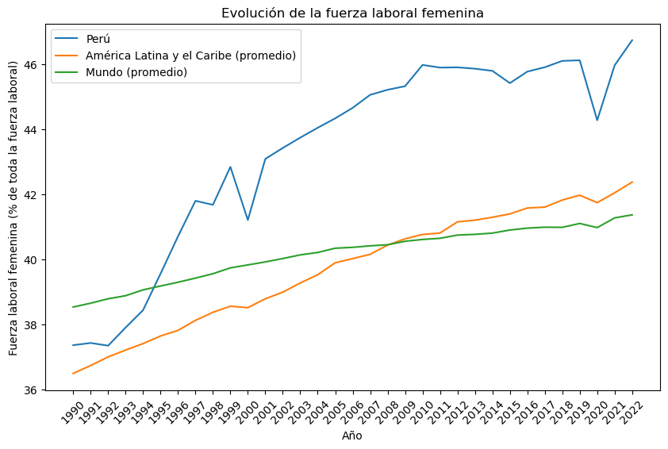

```python
plt.figure(figsize=(10, 6))
plt.plot(flf_total.index, flf_total['fl_peru'], label='Perú')
plt.plot(flf_total.index, flf_total['fl_lac'], label='América Latina y el Caribe (promedio)')
plt.plot(flf_total.index, flf_total['fl_world'], label='Mundo (promedio)')
plt.legend(loc='upper left')
plt.xticks(flf_total.index[30::], rotation=45)
plt.xlabel('Año')
plt.ylabel('Fuerza laboral femenina (% de toda la fuerza laboral)')
plt.title('Evolución de la fuerza laboral femenina')
plt.show()
```

## Emisiones de CO2 y crecimiento del PBI a nivel mundial

### 1. Limpieza de la base de datos

Primero, se filtra la base de datos para obtener solo las emisiones del CO2. También se reemplaza los valores missing con numpy para que sean float y poder pasar todos los valores de string a float.

```python
co2 = pd.read_csv('desarrollo_global.csv')
co2 = co2.loc[((female_lf['Series Name'] == 'CO2 emissions (metric tons per capita)'))]
co2 = co2[co2.columns[~co2.columns.isin(['Country Name', 'Country Code', 'Series Name','Series Code'])]]
co2.columns = yrs
co2.replace('..', np.nan, inplace=True)
co2 = co2.astype(float)

co2
```

|  | 1960 | 1961 | 1962 | 1963 | 1964 | 1965 | 1966 | 1967 | 1968 | 1969 | ... | 2013 | 2014 | 2015 | 2016 | 2017 | 2018 | 2019 | 2020 | 2021 | 2022 |
| --- | --- | --- | --- | --- | --- | --- | --- | --- | --- | --- | --- | --- | --- | --- | --- | --- | --- | --- | --- | --- | --- |
| 2 | NaN | NaN | NaN | NaN | NaN | NaN | NaN | NaN | NaN | NaN | ... | 0.298088 | 0.283692 | 0.297972 | 0.268359 | 0.281196 | 0.299083 | 0.297564 | 0.223479 | NaN | NaN |
| 8 | NaN | NaN | NaN | NaN | NaN | NaN | NaN | NaN | NaN | NaN | ... | 1.656390 | 1.795712 | 1.665219 | 1.590069 | 1.880557 | 1.854642 | 1.749462 | 1.544550 | NaN | NaN |
| 14 | NaN | NaN | NaN | NaN | NaN | NaN | NaN | NaN | NaN | NaN | ... | 3.658469 | 3.811521 | 3.951961 | 3.833834 | 3.833681 | 3.924299 | 3.994402 | 3.718223 | NaN | NaN |
| 20 | NaN | NaN | NaN | NaN | NaN | NaN | NaN | NaN | NaN | NaN | ... | NaN | NaN | NaN | NaN | NaN | NaN | NaN | NaN | NaN | NaN |
| 26 | NaN | NaN | NaN | NaN | NaN | NaN | NaN | NaN | NaN | NaN | ... | 6.674233 | 6.445931 | 6.485769 | 6.465288 | 6.302098 | 6.594057 | 6.287204 | 5.777148 | NaN | NaN |
| ... | ... | ... | ... | ... | ... | ... | ... | ... | ... | ... | ... | ... | ... | ... | ... | ... | ... | ... | ... | ... | ... |
| 1568 | NaN | NaN | NaN | NaN | NaN | NaN | NaN | NaN | NaN | NaN | ... | 0.790532 | 0.802872 | 0.763984 | 0.754344 | 0.743930 | 0.740880 | 0.743359 | 0.660876 | NaN | NaN |
| 1574 | NaN | NaN | NaN | NaN | NaN | NaN | NaN | NaN | NaN | NaN | ... | 0.790174 | 0.802482 | 0.763559 | 0.753867 | 0.743461 | 0.740394 | 0.742893 | 0.660413 | NaN | NaN |
| 1580 | NaN | NaN | NaN | NaN | NaN | NaN | NaN | NaN | NaN | NaN | ... | 0.790532 | 0.802872 | 0.763984 | 0.754344 | 0.743930 | 0.740880 | 0.743359 | 0.660876 | NaN | NaN |
| 1586 | NaN | NaN | NaN | NaN | NaN | NaN | NaN | NaN | NaN | NaN | ... | 5.885588 | 5.857718 | 5.735859 | 5.687045 | 5.773008 | 5.947017 | 6.012487 | 5.923960 | NaN | NaN |
| 1592 | NaN | NaN | NaN | NaN | NaN | NaN | NaN | NaN | NaN | NaN | ... | 4.719666 | 4.682408 | 4.601684 | 4.558579 | 4.578381 | 4.642145 | 4.582573 | 4.292269 | NaN | NaN |

266 rows × 63 columns

Para facilitar el merge, se calcula un promedio mundial para cada año, después de transponer la base de datos anterior.

```python
co2 = co2.transpose()

co2['co2'] = co2.mean(axis=1)

co2 = co2[co2.columns[co2.columns.isin(['co2'])]]
co2
```

|  | co2 |
| --- | --- |
| 1960 | NaN |
| 1961 | NaN |
| 1962 | NaN |
| 1963 | NaN |
| 1964 | NaN |
| ... | ... |
| 2018 | 4.102909 |
| 2019 | 4.044442 |
| 2020 | 3.767934 |
| 2021 | NaN |
| 2022 | NaN |

63 rows × 1 columns

Se repite el mismo proceso para el crecimiento del PBI.

```python
gdp = pd.read_csv('desarrollo_global.csv')
gdp = gdp.loc[((female_lf['Series Name'] == 'GDP growth (annual %)'))]
gdp = gdp[gdp.columns[~gdp.columns.isin(['Country Name', 'Country Code', 'Series Name','Series Code'])]]
gdp.columns = yrs
gdp.replace('..', np.nan, inplace=True)
gdp = gdp.astype(float)
gdp
```

|  | 1960 | 1961 | 1962 | 1963 | 1964 | 1965 | 1966 | 1967 | 1968 | 1969 | ... | 2013 | 2014 | 2015 | 2016 | 2017 | 2018 | 2019 | 2020 | 2021 | 2022 |
| --- | --- | --- | --- | --- | --- | --- | --- | --- | --- | --- | --- | --- | --- | --- | --- | --- | --- | --- | --- | --- | --- |
| 3 | NaN | NaN | NaN | NaN | NaN | NaN | NaN | NaN | NaN | NaN | ... | 5.600745 | 2.724543 | 1.451315 | 2.260314 | 2.647003 | 1.189228 | 3.911603 | -2.351101 | -20.738839 | NaN |
| 9 | NaN | NaN | NaN | NaN | NaN | NaN | NaN | NaN | NaN | NaN | ... | 1.002018 | 1.774449 | 2.218726 | 3.314981 | 3.802599 | 4.019346 | 2.087712 | -3.302082 | 8.908528 | 4.856402 |
| 15 | NaN | -13.605441 | -19.685042 | 34.313729 | 5.839413 | 6.206898 | -4.804971 | 9.452963 | 10.796239 | 8.433280 | ... | 2.800000 | 3.800000 | 3.700000 | 3.200000 | 1.300000 | 1.200000 | 1.000000 | -5.100000 | 3.400000 | 3.200002 |
| 21 | NaN | NaN | NaN | NaN | NaN | NaN | NaN | NaN | NaN | NaN | ... | -2.500000 | 1.762821 | 3.149606 | -1.679389 | -6.987578 | 2.671119 | -0.487805 | 4.411765 | -0.782473 | 1.735016 |
| 27 | NaN | NaN | NaN | NaN | NaN | NaN | NaN | NaN | NaN | NaN | ... | -3.547597 | 2.504466 | 1.434140 | 3.709678 | 0.346072 | 1.588765 | 2.015548 | -11.183940 | 8.287200 | 8.809579 |
| ... | ... | ... | ... | ... | ... | ... | ... | ... | ... | ... | ... | ... | ... | ... | ... | ... | ... | ... | ... | ... | ... |
| 1569 | NaN | 0.977380 | 6.048576 | 6.100847 | 4.956462 | 4.773029 | 1.357426 | -1.225410 | 2.976491 | 9.375582 | ... | 5.058056 | 4.866911 | 2.896515 | 1.280172 | 2.444259 | 2.646421 | 2.559391 | -1.961830 | 4.153095 | 3.585452 |
| 1575 | NaN | 0.980916 | 6.047241 | 6.098513 | 4.955884 | 4.776562 | 1.350254 | -1.226522 | 2.973521 | 9.381936 | ... | 5.061283 | 4.867565 | 2.895466 | 1.277042 | 2.443968 | 2.645517 | 2.557396 | -1.956754 | 4.152040 | 3.580911 |
| 1581 | NaN | 0.977380 | 6.048576 | 6.100847 | 4.956462 | 4.773029 | 1.357426 | -1.225410 | 2.976491 | 9.375582 | ... | 5.058056 | 4.866911 | 2.896515 | 1.280172 | 2.444259 | 2.646421 | 2.559391 | -1.961830 | 4.153095 | 3.585452 |
| 1587 | NaN | 0.176220 | 3.253635 | 3.580183 | 8.505536 | 6.889678 | 6.027227 | 3.166519 | 5.828765 | 7.673989 | ... | 5.531851 | 4.705957 | 4.294246 | 4.215761 | 5.205582 | 4.938959 | 4.122023 | -0.683348 | 7.584939 | 3.123288 |
| 1593 | NaN | 3.791102 | 5.314740 | 5.190264 | 6.562107 | 5.555102 | 5.711068 | 4.155676 | 5.949692 | 5.810836 | ... | 2.799773 | 3.066935 | 3.069793 | 2.785986 | 3.396183 | 3.276979 | 2.590376 | -3.065637 | 6.202165 | 3.086928 |

266 rows × 63 columns

```python
gdp = gdp.transpose()

gdp['gdp'] = gdp.mean(axis=1)

gdp = gdp[gdp.columns[gdp.columns.isin(['gdp'])]]
gdp
```

|  | gdp |
| --- | --- |
| 1960 | NaN |
| 1961 | 3.308166 |
| 1962 | 5.048257 |
| 1963 | 4.947116 |
| 1964 | 6.234636 |
| ... | ... |
| 2018 | 3.072767 |
| 2019 | 2.797521 |
| 2020 | -4.790939 |
| 2021 | 5.446574 |
| 2022 | 4.224529 |

63 rows × 1 columns

### 2. Merge del los datos obtenidos

```python
co2_gdp = co2.merge(gdp, left_index=True, right_index=True)

co2_gdp
```

|  | co2 | gdp |
| --- | --- | --- |
| 1960 | NaN | NaN |
| 1961 | NaN | 3.308166 |
| 1962 | NaN | 5.048257 |
| 1963 | NaN | 4.947116 |
| 1964 | NaN | 6.234636 |
| ... | ... | ... |
| 2018 | 4.102909 | 3.072767 |
| 2019 | 4.044442 | 2.797521 |
| 2020 | 3.767934 | -4.790939 |
| 2021 | NaN | 5.446574 |
| 2022 | NaN | 4.224529 |

63 rows × 2 columns

### 3. Elaboración del scatter plot para visualizar la relación entre crecimiento del PBI y emisión de CO2

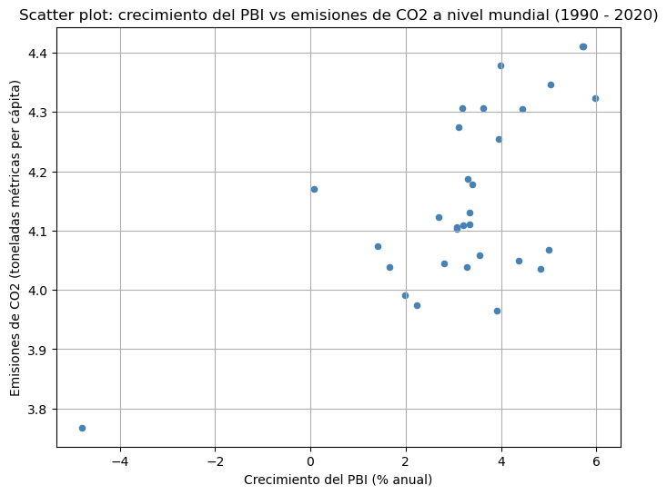

```python
co2_gdp.plot(kind='scatter', x='gdp', y='co2', figsize=(8, 6), color='steelblue')

plt.title('Scatter plot: crecimiento del PBI vs emisiones de CO2 a nivel mundial (1990 - 2020)')
plt.ylabel('Emisiones de CO2 (toneladas métricas per cápita)')
plt.xlabel('Crecimiento del PBI (% anual)')
plt.grid(True)


plt.show()
```

## Acceso a la electricidad en Perú

```python
electricity_df = pd.read_csv('desarrollo_global.csv')

peru_electricity = electricity_df.loc[
    (electricity_df['Country Name'] == 'Peru') &
    (electricity_df['Series Name'] == 'Access to electricity (% of population)')
]

peru_electricity = peru_electricity[
    peru_electricity.columns[~peru_electricity.columns.isin(['Country Name', 'Country Code', 'Series Name', 'Series Code'])]
]

peru_electricity
```

|  | 1960 [YR1960] | 1961 [YR1961] | 1962 [YR1962] | 1963 [YR1963] | 1964 [YR1964] | 1965 [YR1965] | 1966 [YR1966] | 1967 [YR1967] | 1968 [YR1968] | 1969 [YR1969] | ... | 2013 [YR2013] | 2014 [YR2014] | 2015 [YR2015] | 2016 [YR2016] | 2017 [YR2017] | 2018 [YR2018] | 2019 [YR2019] | 2020 [YR2020] | 2021 [YR2021] | 2022 [YR2022] |
| --- | --- | --- | --- | --- | --- | --- | --- | --- | --- | --- | --- | --- | --- | --- | --- | --- | --- | --- | --- | --- | --- |
| 924 | .. | .. | .. | .. | .. | .. | .. | .. | .. | .. | ... | 92.135365 | 92.919989 | 93.852179 | 94.2 | 94.8 | 95.2 | 95.551360223182 | 96.2 | 95.6 | .. |

1 rows × 63 columns

```python
peru_electricity.columns = yrs
peru_electricity.replace('..', np.nan, inplace=True)
peru_electricity = peru_electricity.astype(float)
peru_electricity
```

|  | 1960 | 1961 | 1962 | 1963 | 1964 | 1965 | 1966 | 1967 | 1968 | 1969 | ... | 2013 | 2014 | 2015 | 2016 | 2017 | 2018 | 2019 | 2020 | 2021 | 2022 |
| --- | --- | --- | --- | --- | --- | --- | --- | --- | --- | --- | --- | --- | --- | --- | --- | --- | --- | --- | --- | --- | --- |
| 924 | NaN | NaN | NaN | NaN | NaN | NaN | NaN | NaN | NaN | NaN | ... | 92.135365 | 92.919989 | 93.852179 | 94.2 | 94.8 | 95.2 | 95.55136 | 96.2 | 95.6 | NaN |

1 rows × 63 columns

```python
tperu_electricity = peru_electricity.transpose()
tperu_electricity.columns = ['Electricidad (%)']
tperu_electricity
```

|  | Electricidad (%) |
| --- | --- |
| 1960 | NaN |
| 1961 | NaN |
| 1962 | NaN |
| 1963 | NaN |
| 1964 | NaN |
| ... | ... |
| 2018 | 95.20000 |
| 2019 | 95.55136 |
| 2020 | 96.20000 |
| 2021 | 95.60000 |
| 2022 | NaN |

63 rows × 1 columns

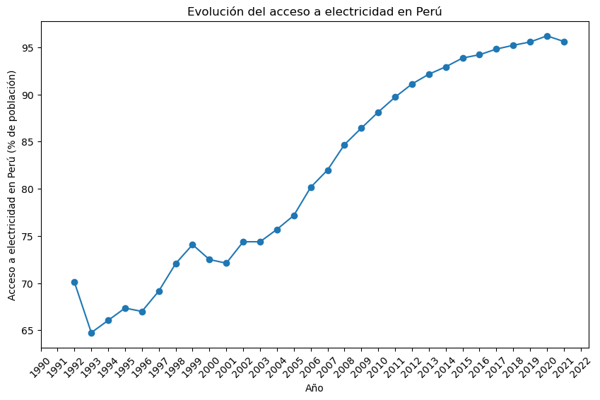

```python
plt.figure(figsize=(10, 6))
plt.plot(tperu_electricity.index, tperu_electricity['Electricidad (%)'], label='Perú', marker='o')
plt.xticks(tperu_electricity.index[30::], rotation=45)
plt.xlabel('Año')
plt.ylabel('Acceso a electricidad en Perú (% de población)')
plt.title('Evolución del acceso a electricidad en Perú')
plt.show()
```

## Acceso a la electricidad y emisiones de CO2

```python
electricity = pd.read_csv('desarrollo_global.csv')

electricity = electricity.loc[electricity['Series Name'] == 'Access to electricity (% of population)']
electricity = electricity.drop(columns=['Country Name', 'Country Code', 'Series Name', 'Series Code'])
electricity.columns = electricity.columns.str.strip()
electricity.replace('..', np.nan, inplace=True)
electricity = electricity.astype(float)
electricity.columns = yrs
electricity
```

|  | 1960 | 1961 | 1962 | 1963 | 1964 | 1965 | 1966 | 1967 | 1968 | 1969 | ... | 2013 | 2014 | 2015 | 2016 | 2017 | 2018 | 2019 | 2020 | 2021 | 2022 |
| --- | --- | --- | --- | --- | --- | --- | --- | --- | --- | --- | --- | --- | --- | --- | --- | --- | --- | --- | --- | --- | --- |
| 0 | NaN | NaN | NaN | NaN | NaN | NaN | NaN | NaN | NaN | NaN | ... | 68.040878 | 89.500000 | 71.500000 | 97.700000 | 97.700000 | 93.430878 | 97.700000 | 97.700000 | 97.700000 | NaN |
| 6 | NaN | NaN | NaN | NaN | NaN | NaN | NaN | NaN | NaN | NaN | ... | 99.890312 | 99.950000 | 99.980000 | 99.890000 | 99.890000 | 100.000000 | 100.000000 | 100.000000 | 100.000000 | NaN |
| 12 | NaN | NaN | NaN | NaN | NaN | NaN | NaN | NaN | NaN | NaN | ... | 99.187927 | 99.274551 | 99.356194 | 99.433693 | 99.530022 | 99.637741 | 99.500000 | 99.718773 | 99.787827 | NaN |
| 18 | NaN | NaN | NaN | NaN | NaN | NaN | NaN | NaN | NaN | NaN | ... | NaN | NaN | NaN | NaN | NaN | NaN | NaN | NaN | NaN | NaN |
| 24 | NaN | NaN | NaN | NaN | NaN | NaN | NaN | NaN | NaN | NaN | ... | 100.000000 | 100.000000 | 100.000000 | 100.000000 | 100.000000 | 100.000000 | 100.000000 | 100.000000 | 100.000000 | NaN |
| ... | ... | ... | ... | ... | ... | ... | ... | ... | ... | ... | ... | ... | ... | ... | ... | ... | ... | ... | ... | ... | ... |
| 1566 | NaN | NaN | NaN | NaN | NaN | NaN | NaN | NaN | NaN | NaN | ... | 37.920967 | 38.259012 | 39.112098 | 43.733941 | 43.678548 | 46.344739 | 47.132521 | 48.481837 | 50.581484 | NaN |
| 1572 | NaN | NaN | NaN | NaN | NaN | NaN | NaN | NaN | NaN | NaN | ... | 37.915308 | 38.253265 | 39.106459 | 43.728799 | 43.673474 | 46.339986 | 47.127919 | 48.477431 | 50.577331 | NaN |
| 1578 | NaN | NaN | NaN | NaN | NaN | NaN | NaN | NaN | NaN | NaN | ... | 37.920967 | 38.259012 | 39.112098 | 43.733941 | 43.678548 | 46.344739 | 47.132521 | 48.481837 | 50.581484 | NaN |
| 1584 | NaN | NaN | NaN | NaN | NaN | NaN | NaN | NaN | NaN | NaN | ... | 98.801080 | 98.895346 | 98.739875 | 98.981041 | 99.144532 | 99.153415 | 99.235945 | 99.178418 | 99.403982 | NaN |
| 1590 | NaN | NaN | NaN | NaN | NaN | NaN | NaN | NaN | NaN | NaN | ... | 85.816522 | 86.305222 | 87.022731 | 88.189630 | 89.016961 | 89.891872 | 90.193562 | 90.482703 | 91.414096 | NaN |

266 rows × 63 columns

```python
electricity = electricity.mean(axis=0).to_frame(name='electricity')
electricity.index.name = 'Year'
electricity
```

| Year | electricity |
| --- | --- |
| 1960 | NaN |
| 1961 | NaN |
| 1962 | NaN |
| 1963 | NaN |
| 1964 | NaN |
| ... | ... |
| 2018 | 85.134465 |
| 2019 | 85.689777 |
| 2020 | 86.221767 |
| 2021 | 86.781638 |
| 2022 | NaN |

63 rows × 1 columns

```python
co2_elec = co2.merge(electricity, left_index=True, right_index=True)

co2_elec
```

|  | co2 | electricity |
| --- | --- | --- |
| 1960 | NaN | NaN |
| 1961 | NaN | NaN |
| 1962 | NaN | NaN |
| 1963 | NaN | NaN |
| 1964 | NaN | NaN |
| ... | ... | ... |
| 2018 | 4.102909 | 85.134465 |
| 2019 | 4.044442 | 85.689777 |
| 2020 | 3.767934 | 86.221767 |
| 2021 | NaN | 86.781638 |
| 2022 | NaN | NaN |

63 rows × 2 columns

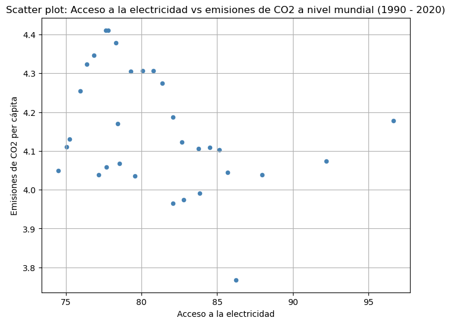

```python
co2_elec.plot(kind='scatter', x='electricity', y='co2', figsize=(8, 6), color='steelblue')

plt.title('Scatter plot: Acceso a la electricidad vs emisiones de CO2 a nivel mundial (1990 - 2020)')
plt.xlabel('Acceso a la electricidad')
plt.ylabel('Emisiones de CO2 per cápita')
plt.grid(True)

plt.show()
```